# newbie_workshop

## 10.3.5.ふたたび線形回帰分析

- 手順は同じ

```r
# Tooth_length = b0 + b1*Supplement + b2*Dose + b3*Supplement*Dose
ToothGrowth_lm_result <- lm(Tooth_length ~ Supplement * Dose, data = ToothGrowth2)
summary(ToothGrowth_lm_result)
```

```
#>
#> Call:
#> lm(formula = Tooth_length ~ Supplement * Dose, data = ToothGrowth2)
#>
#> Residuals:
#>     Min      1Q  Median      3Q     Max
#> -8.2264 -2.8462  0.0504  2.2893  7.9386
#>
#> Coefficients:
#>                   Estimate Std. Error t value Pr(>|t|)
#> (Intercept)         11.550      1.581   7.304 1.09e-09 ***
#> SupplementVC        -8.255      2.236  -3.691 0.000507 ***
#> Dose                 7.811      1.195   6.534 2.03e-08 ***
#> SupplementVC:Dose    3.904      1.691   2.309 0.024631 *
#> ---
#> Signif. codes:  0 '***' 0.001 '**' 0.01 '*' 0.05 '.' 0.1 ' ' 1
#>
#> Residual standard error: 4.083 on 56 degrees of freedom
#> Multiple R-squared:  0.7296, Adjusted R-squared:  0.7151
#> F-statistic: 50.36 on 3 and 56 DF,  p-value: 6.521e-16
```

- ggplotを使っていく
- 見やすい方

```r
ToothGrowth2 <- ToothGrowth2 %>%
  mutate(
    Supplement_num = unclass(.$Supplement),
    Tooth_length_res = predict(ToothGrowth_lm_result)
  )
ToothGrowth2 %>% head() %>% knitr::kable()
```

| Tooth_length | Supplement | Dose | Supplement_num | Tooth_length_res |
| --- | --- | --- | --- | --- |
| 4.2 | VC | 0.5 | 2 | 9.152857 |
| 11.5 | VC | 0.5 | 2 | 9.152857 |
| 7.3 | VC | 0.5 | 2 | 9.152857 |
| 5.8 | VC | 0.5 | 2 | 9.152857 |
| 6.4 | VC | 0.5 | 2 | 9.152857 |
| 10.0 | VC | 0.5 | 2 | 9.152857 |

[figure not shown]

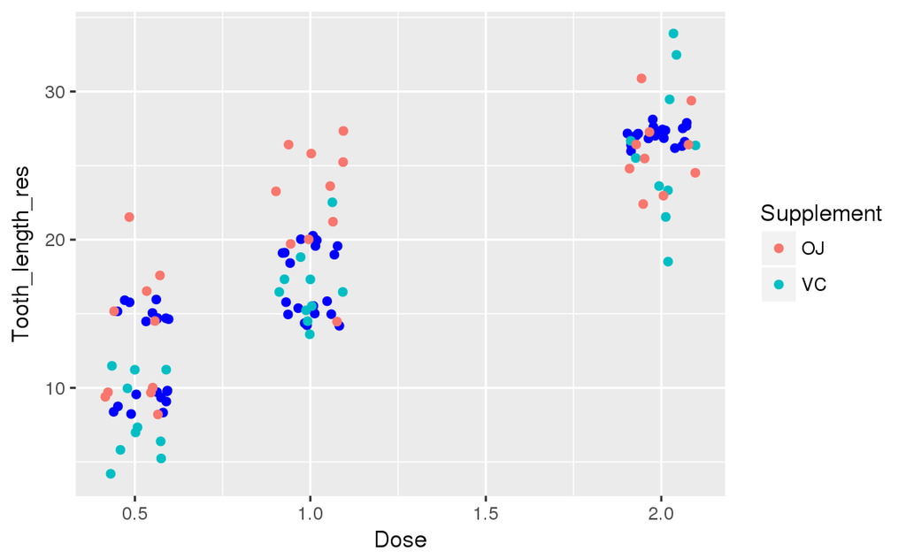

```r
ToothGrowth2 %>%
  ggplot(aes(Dose, color = Supplement)) +
  geom_point(aes(y = Tooth_length_res), position = position_jitter(width = 0.1, height = 1), color = "#0000ff") +
  geom_point(aes(y = Tooth_length), position = position_jitter(width = 0.1))
```

- 95%信頼区間でのみ`b3 * Supplement * Dose`が棄却される。
- イテレーションしたらもう少し違うかも。

# 11.rmarkdown

## 11.1.rmarkdownの準備

- File > New File > R markdown > Document HTML(ラジオボタン) > OK
- はじめてrmdファイルを作ろうとするとエラーが出る
- とりあえず，インストールしてください。

```r
install.packages(c("bitops", "caTools"))
```

## 11.2.yamlヘッダ

- 出力するファイルのオプションを設定

```
---
title: "たいとる"
author: "書いた人"
date: "日付"
output: 出力形式:
    css: "cssのパス"
    self_contained: TRUEかFALSE
---
```

## 11.3.出力形式

| 指定方法 | 出力形式 |
| --- | --- |
| html_document | html |
| pdf_document | pdf |
| word_document | word |
| ioslides_presentation | htmlのスライド |
| revealjs::revealjs_presentation | イケてるスライド |
| bookdown::gitbook | 本 |

- 他にもいろいろな出力形式がある。
- pdfはlatexをつかうので、ハマる。

```r
#CRANから
install.packages("revealjs")

#githubから
install.packages("devtools")
install_github("rstudio/revealjs")
```

```r
install.packages("bookdown")
```

## 11.3.1.pdfの出力

- pdfを出力するとエラーが出る
- texライブラリが足りないみたい

```
output: pdf_document

Ctrl + Shift + K (knit)
```

## 11.3.2.texのログファイル

- pdfをレンダリングするとログが出るので読む
  - 大事なところだけでいい

```
! LaTeX Error: File `titling.sty' not found.
!  ==> Fatal error occurred, no output PDF file produced!
```

- `titling.sty`がないということ

## 11.3.3.texライブラリ

- texライブラリを追加すればOK

```bash
wget ftp://ftp.jaist.ac.jp/pub/CTAN/macros/latex/contrib/titling.zip
unzip titling.zip
cd titling.zip
latex titling.ins
sudo cp titling.sty /usr/share/texlive/texmf-dist/tex/latex/titling/
sudo texhash
```

- 必要ないかもだけど一応

```
# You are recommended to install the tinytex package to build PDF.FALSE
On Rstudio
install.packages("tinytex")
```

# 11.4.コードチャンク

## 11.4.1.コードチャンクの書き方

- 先頭の\はエスケープです。
- 取り除いてください。

````
\```{r}
\Rのコード
\```
````

- `Ctrl + Alt + I` でチャンクを追加できる

## 11.4.2.チャンクオプション

- `{r チャンク名, オプションの指定}`

| オプション | T, F | 結果 |
| --- | --- | --- |
| include | FALSE | コードと結果を表示しない |
| echo | FALSE | コードを表示しない |
| message | FALSE | メッセージを表示しない |
| eval | FALSE | 実行しない |

- ほかにもいろいろある
- オプションのチェック方法
  - `knitr::opts_chunk$get`

## 11.4.3.setupチャンク

- `{r setup, include = FALSE}`
- setupのチャンクは一度しか使えない。
- `include = FALSE`がよく使う指定。
  - コードチャンクを表示しない
- 今回は次のように設定してある。
- bookdownは違う設定をしてある。

````
\```{r setup, include=FALSE}
knitr::opts_chunk$set(
  comment = "#>",
  collapse = TRUE,
  fig.show = "hold"
)
\```
````

## 11.4.4.エンジン

- `{r チャンク名, engine="言語名"}`
- ````言語名:チャンク名`
- `{言語名 チャンク名, オプション}`

他言語 に書いた言語以外にもいろいろ使える。

## 11.4.5.tex数式

- インラインは`$数式$`
- ブロックラインは`$$数式$$`

たとえば,$E=mc^2$, $mgh=\frac{1}{2}mv^2$

$$E=mc^2$$
$$mgh=\frac{1}{2}mv^2$$

## 11.4.6.texコマンド

- コマンドは\をつける

| コマンド | 効果 |
| --- | --- |
| `\text` | 演算子など記号を文字にする |
| `{\rm }` | 文字がイタリックになるのをやめる |
| `_{}` | 下付き文字 |
| `^{}` | 上付き文字 |
| `\theta` | $\theta$ギリシャ文字(ほかにも使えます) |
| `\frac{a}{b}` | $\frac{a}{b}$の分数をつくる |
| `\int_a^b` | $\int_a^b$こんな感じの積分を作る |

# 12.1.shiny

## 12.1.1.shinyってなんぞ

- Rでwebアプリを作れるやつ
- shinyパッケージをインストールする
- shinyサーバーをインストールして構築するのは難易度高め

## reactive

```r
ui <- fluidPage(
  titlePanel("たいとる"),
  mainPanel(),
  sidebarPanel()
)

server <- function(input, output) {

}

shinyApp(ui = ui, server = server)
```

Shiny applications not supported in static R Markdown documents

## observer

## endpoint

# htmlwidget

## leaflet

## libpng

## DiagrammeR

# 動的処理

## eval, substitute, paste

## benchmark

# 他言語２

## 組み合わせ

# さいごに

今回は，他言語との連携をメインにRを紹介しました。  
ここでは触れなかったことの方が多いです。  
統計だけじゃない，Rを楽しみましょう！

# 付録

# 環境構築

## virtualbox

## vagrant

### rstudio-server

## Vagrantfile

## Nginx

## Shiny-server

## 参考資料

- [アート・オブ・Rプログラミング](https://www.oreilly.co.jp/books/9784873115795/)
- [R for Data Science](http://r4ds.had.co.nz/)